# Subject 1001B: T2 Hippocampal Subfields

Shuying Yu

07/10/2023

# Overview

This report provides descriptive statistics for T2 hippocampal subfield data (raw from ASHS, to make comparisons with 1001B) from the Healthy Aging Study sample (subjects 333 - 437, with 1001B appended).

*Sample size:*

- Men = 24
- Women = 63 (24 pre, 20 peri, 19 post)

# T2 Subfield Volume

## CA1

Subject 1001B: average volume of 0.4954585

### Structural Comparison

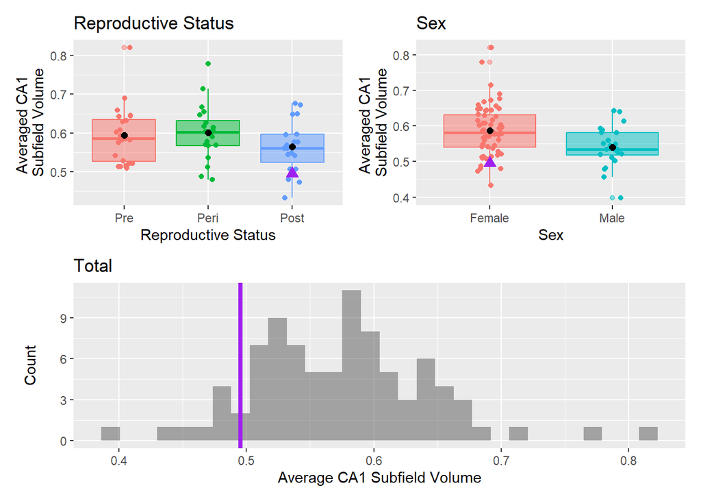

|  | Df | Sum Sq | Mean Sq | F value | Pr(>F) |
| --- | --- | --- | --- | --- | --- |
| repo_status | 2 | 0.0151012 | 0.0075506 | 1.520983 | 0.2268011 |
| Residuals | 60 | 0.2978570 | 0.0049643 | NA | NA |

ANOVA results comparing CA1 subfield by reproductive status was not significant.

```
##
##  Welch Two Sample t-test
##
## data:  avg_ca1 by sex
## t = 3.216, df = 52.242, p-value = 0.002232
## alternative hypothesis: true difference in means between group Female and group Male is not equal to 0
## 95 percent confidence interval:
##  0.01761859 0.07607124
## sample estimates:
## mean in group Female   mean in group Male
##            0.5872078            0.5403629
```

T-test results comparing CA1 subfield by sex was significant.

## CA2/3

Subject 1001B: average volume of 0.1919011

### Structural Comparison

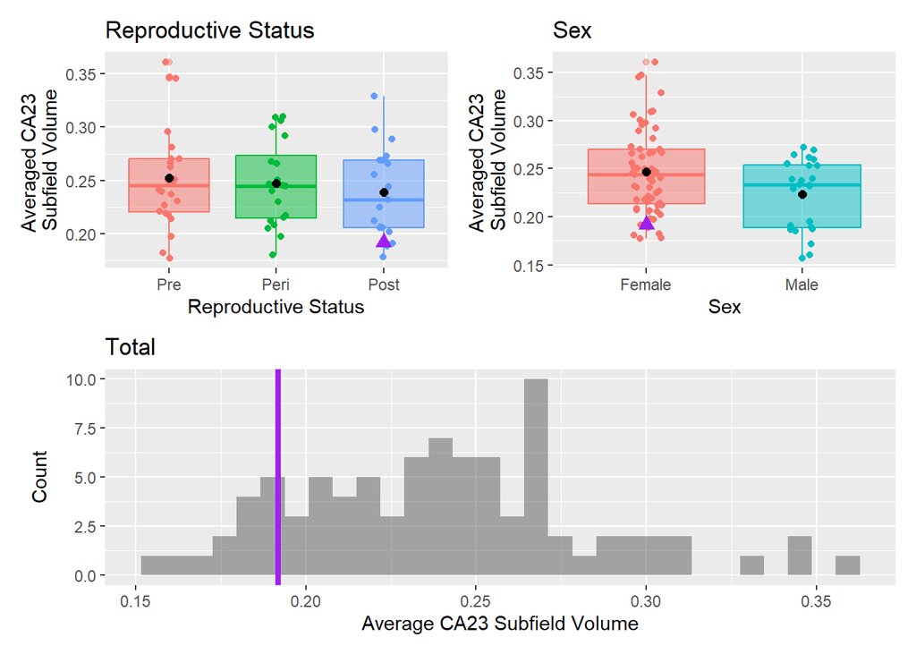

|  | Df | Sum Sq | Mean Sq | F value | Pr(>F) |
| --- | --- | --- | --- | --- | --- |
| repo_status | 2 | 0.0019035 | 0.0009517 | 0.493987 | 0.6126484 |
| Residuals | 60 | 0.1155978 | 0.0019266 | NA | NA |

ANOVA results comparing CA23 subfield by reproductive status was not significant.

```
##
##  Welch Two Sample t-test
##
## data:  avg_ca23 by sex
## t = 2.5392, df = 48.975, p-value = 0.01434
## alternative hypothesis: true difference in means between group Female and group Male is not equal to 0
## 95 percent confidence interval:
##  0.004920838 0.042268912
## sample estimates:
## mean in group Female   mean in group Male
##            0.2467289            0.2231340
```

T-test results comparing CA23 subfield by sex was significant.

## DG

Subject 1001B: average volume of 0.4619523

### Structural Comparison

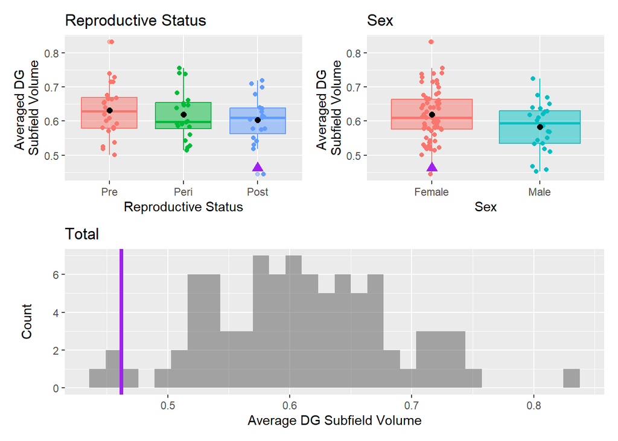

|  | Df | Sum Sq | Mean Sq | F value | Pr(>F) |
| --- | --- | --- | --- | --- | --- |
| repo_status | 2 | 0.0083941 | 0.0041971 | 0.750208 | 0.4766459 |
| Residuals | 60 | 0.3356715 | 0.0055945 | NA | NA |

ANOVA results comparing DG subfield by reproductive status was not significant.

```
##
##  Welch Two Sample t-test
##
## data:  avg_dg by sex
## t = 2.0854, df = 43.206, p-value = 0.04298
## alternative hypothesis: true difference in means between group Female and group Male is not equal to 0
## 95 percent confidence interval:
##  0.00119681 0.07118450
## sample estimates:
## mean in group Female   mean in group Male
##            0.6192800            0.5830894
```

T-test results comparing DG subfield by sex was significant.

## ERC

Subject 1001B: average volume of 0.3473447

### Structural Comparison

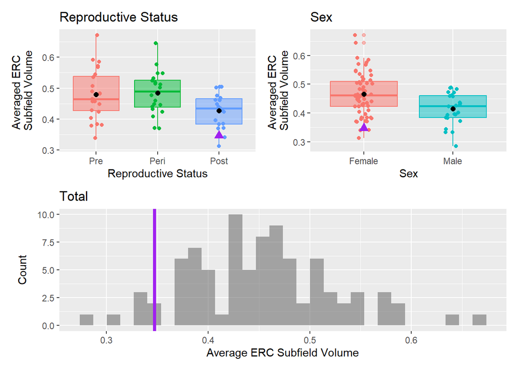

|  | Df | Sum Sq | Mean Sq | F value | Pr(>F) |
| --- | --- | --- | --- | --- | --- |
| repo_status | 2 | 0.0407582 | 0.0203791 | 4.123448 | 0.0209918 |
| Residuals | 60 | 0.2965350 | 0.0049423 | NA | NA |

ANOVA results comparing ERC subfield by reproductive status was significant.

```
##
##  Welch Two Sample t-test
##
## data:  avg_erc by sex
## t = 3.5175, df = 55.723, p-value = 0.0008746
## alternative hypothesis: true difference in means between group Female and group Male is not equal to 0
## 95 percent confidence interval:
##  0.02204370 0.08038099
## sample estimates:
## mean in group Female   mean in group Male
##            0.4655728            0.4143605
```

T-test results comparing ERC subfield by sex was significant.

## PHC

Subject 1001B: average volume of 1.535398

### Structural Comparison

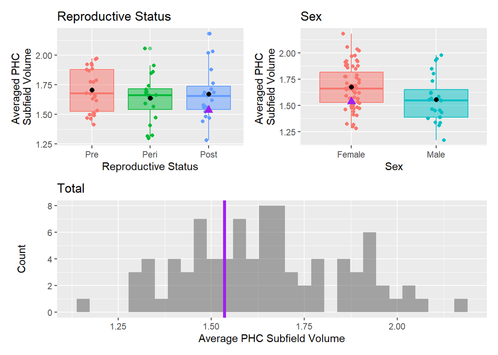

|  | Df | Sum Sq | Mean Sq | F value | Pr(>F) |
| --- | --- | --- | --- | --- | --- |
| repo_status | 2 | 0.0516381 | 0.0258191 | 0.6318458 | 0.5351094 |
| Residuals | 60 | 2.4517754 | 0.0408629 | NA | NA |

ANOVA results comparing PHC subfield by reproductive status was not significant.

```
##
##  Welch Two Sample t-test
##
## data:  avg_phc by sex
## t = 2.2998, df = 38.699, p-value = 0.02694
## alternative hypothesis: true difference in means between group Female and group Male is not equal to 0
## 95 percent confidence interval:
##  0.01419269 0.22180438
## sample estimates:
## mean in group Female   mean in group Male
##             1.674716             1.556717
```

T-test results comparing PHC subfield by sex was significant.

## PRC

Subject 1001B: average volume of 1.191195

### Structural Comparison

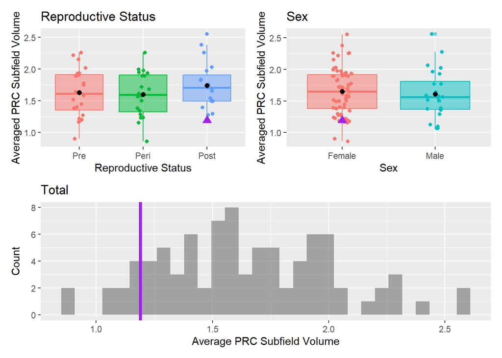

|  | Df | Sum Sq | Mean Sq | F value | Pr(>F) |
| --- | --- | --- | --- | --- | --- |
| repo_status | 2 | 0.211709 | 0.1058545 | 0.7813027 | 0.4624106 |
| Residuals | 60 | 8.129078 | 0.1354846 | NA | NA |

ANOVA results comparing PRC subfield by reproductive status was not significant.

```
##
##  Welch Two Sample t-test
##
## data:  avg_prc by sex
## t = 0.50652, df = 39.953, p-value = 0.6153
## alternative hypothesis: true difference in means between group Female and group Male is not equal to 0
## 95 percent confidence interval:
##  -0.1378815  0.2301021
## sample estimates:
## mean in group Female   mean in group Male
##             1.652974             1.606863
```

T-test results comparing PRC subfield by sex was not significant.

## SUB

Subject 1001B: average volume of 0.2863284

### Structural Comparison

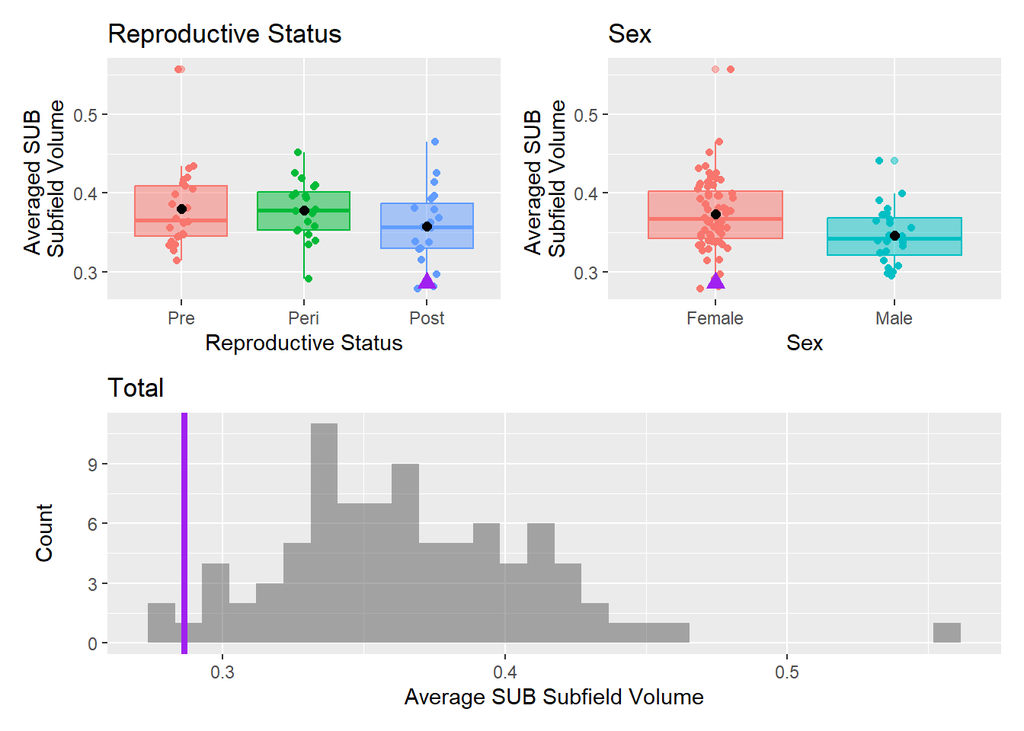

|  | Df | Sum Sq | Mean Sq | F value | Pr(>F) |
| --- | --- | --- | --- | --- | --- |
| repo_status | 2 | 0.0060737 | 0.0030368 | 1.392181 | 0.2564443 |
| Residuals | 60 | 0.1308814 | 0.0021814 | NA | NA |

ANOVA results comparing SUB subfield by reproductive status was not significant.

```
##
##  Welch Two Sample t-test
##
## data:  avg_sub by sex
## t = 2.8303, df = 53.988, p-value = 0.006517
## alternative hypothesis: true difference in means between group Female and group Male is not equal to 0
## 95 percent confidence interval:
##  0.007799812 0.045688732
## sample estimates:
## mean in group Female   mean in group Male
##            0.3732318            0.3464875
```

T-test results comparing SUB subfield by sex was significant.

# Summary